# HW3

Author

Katherine

```r
library(tidyverse)
library(tidytext)
library(ggplot2)
library(tidytext)
library(dplyr)
library(tidyr)
pubmed <- read_csv("/Users/gongxinyu/Downloads/pubmed.csv")
```

**There are 5 documents (terms), which we want to find the abstract highlight. Covid has the highest number of abstract.**

**Question 1**

```r
pubmed %>%
  count(term, name = "number_abstracts")
```

```
# A tibble: 5 × 2
  term            number_abstracts
  <chr>                      <int>
1 covid                        981
2 cystic fibrosis              376
3 meningitis                   317
4 preeclampsia                 780
5 prostate cancer              787
```

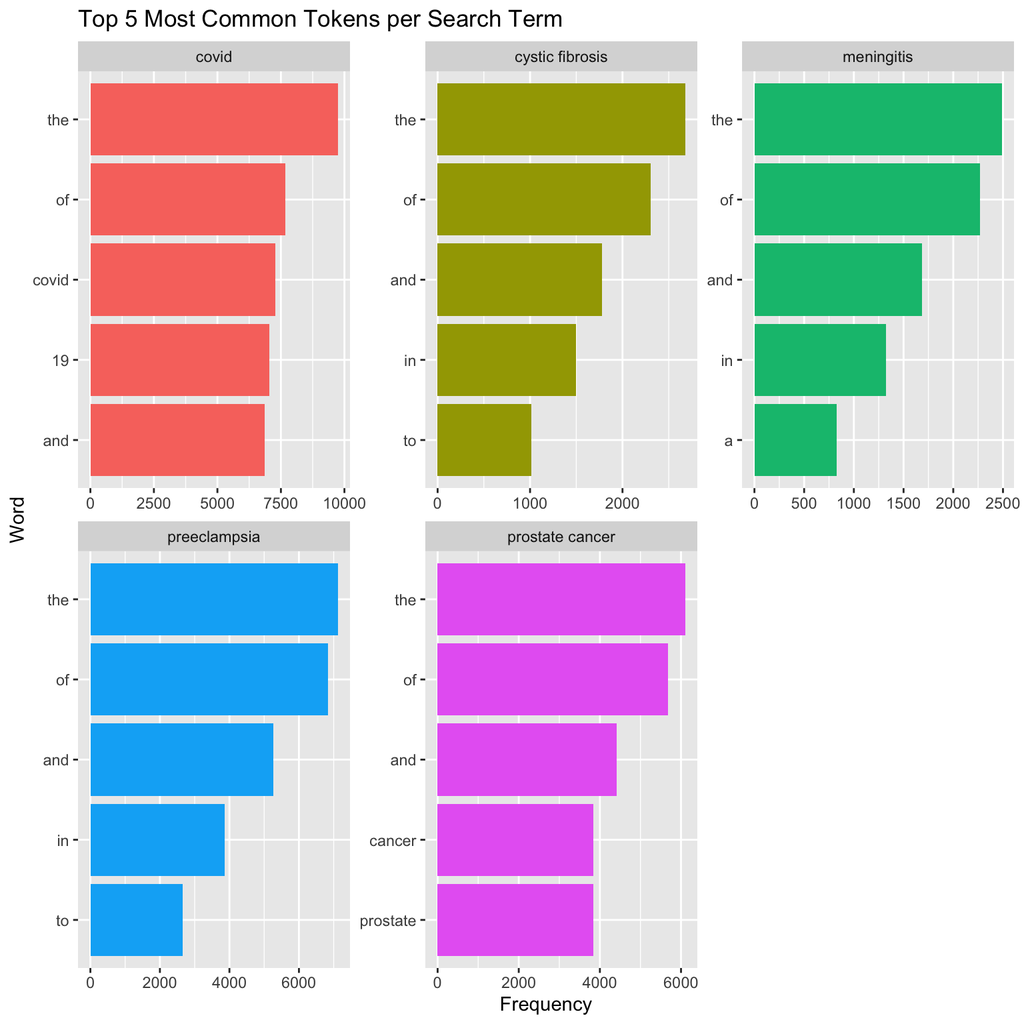

```r
token_counts <- pubmed %>%
  unnest_tokens(word, abstract) %>% #split the word of abstract into each word
  count(term, word, sort = TRUE)

top5_tokens <- token_counts %>%
  group_by(term) %>%  #split the word by term to see the top 5 words
  slice_max(n, n = 5)

top5_tokens %>%
  ggplot(aes(x = reorder_within(word, n, term), y = n, fill = term)) +
  geom_col(show.legend = FALSE) +
  facet_wrap(~ term, scales = "free") +
  coord_flip() +
  scale_x_reordered() +
  labs(title = "Top 5 Most Common Tokens per Search Term",
        x = "Word",
       y = "Frequency")
```

**There are 981 abstracts for COVID, 787 for prostate cancer, 780 for preeclampsia, 376 for cystic fibrosis, and 317 for meningitis. After splitting the abstracts into unigrams, we can see that for COVID, the top five most common words are “the,” “of,” “covid,” “19,” and “and.” For cystic fibrosis, the top five words are “the,” “of,” “and,” “in,” and “to,” and for meningitis, they are “the,” “of,” “and,” “in,” and “a.” Preeclampsia has “the,” “of,” “and,” “in,” and “to” as the top five words, while prostate cancer has “the,” “of,” “and,” “cancer,” and “prostate.” Interestingly, for every search term, “the” is the most common word. This makes sense because it is a stop word that people frequently use in writing. In fact, most of the top five words across all terms—such as “the,” “and,” “of,” “in,” “to,” and “a”—are stop words. I even used many of these stop words while answering this question, so it makes sense that they are the most commonly used words. For prostate cancer and COVID-19, aside from stop words, the disease names themselves also appear among the top five most common words.**

**Question2**

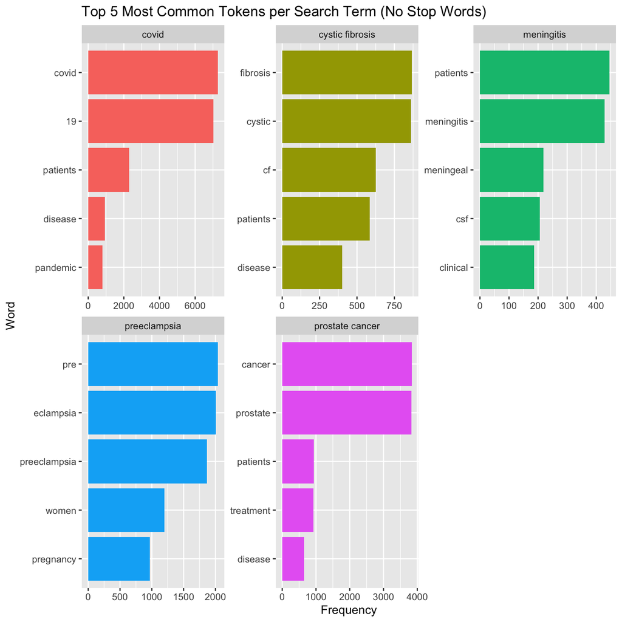

```r
data("stop_words")

token_no_stop <- pubmed %>%
  unnest_tokens(word, abstract) %>%
  anti_join(stop_words, by = "word") %>% #remove words if they belong in stop_words data
  count(term, word, sort = TRUE)

top5_no_stop <- token_no_stop %>%
  group_by(term) %>%
  slice_max(n, n = 5)

top5_no_stop %>%
  ggplot(aes(x = reorder_within(word, n, term),
             y = n,
             fill = term)) +
  geom_col(show.legend = FALSE) +
  facet_wrap(~ term, scales = "free") +
  coord_flip() +
  scale_x_reordered() +
  labs(title = "Top 5 Most Common Tokens per Search Term (No Stop Words)",
       x = "Word",
       y = "Frequency")
```

**After removing the stop words, we can see more meaningful insights from the data. For the single-word (unigram) analysis, COVID-related abstracts include terms such as “covid,” “19,” “patients,” “disease,” and “pandemic,” which aligns with the nature of COVID-19 as a global health crisis. Cystic fibrosis has words “fibrosis”, “cystic”, “cf”, “patients” and “disease”. Meningitis has “patients”, “meningitis”, “meningeal”, “csf”, and “clinical”. Preeclampsia has “pre”, “eclampsia”, “women” and “pregnancy”. Prostate cancer has “cancer”, “prostate”, “patients”, “treatment”, and “disease”. However, words like “patients” and “disease” are still quite general and may need to be treated as additional stop words, since they appear frequently across many medical texts without offering specific context. Interestingly, the search term itself also appears among the top tokens. In contrast, the preeclampsia abstracts provide more interpretable information, as words like “women” and “pregnancy” appear among the top tokens, directly reflecting the condition’s relevance to maternal health**

**Question 3**

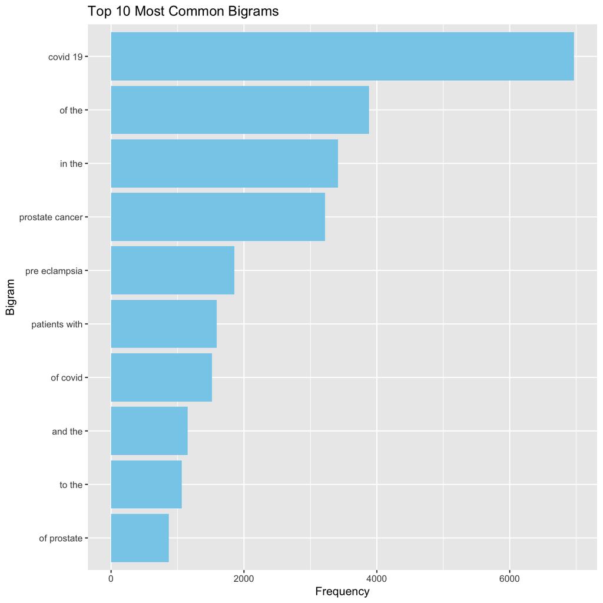

```r
bigrams <- pubmed %>%
  unnest_tokens(bigram, abstract, token = "ngrams", n = 2)

bigrams %>%
  count(bigram, sort = TRUE) %>%
  slice_max(n, n = 10) %>%
  ggplot(aes(x = reorder(bigram, n), y = n)) +
  geom_col(fill = "skyblue") +
  coord_flip() +
  labs(title = "Top 10 Most Common Bigrams", x = "Bigram", y = "Frequency")
```

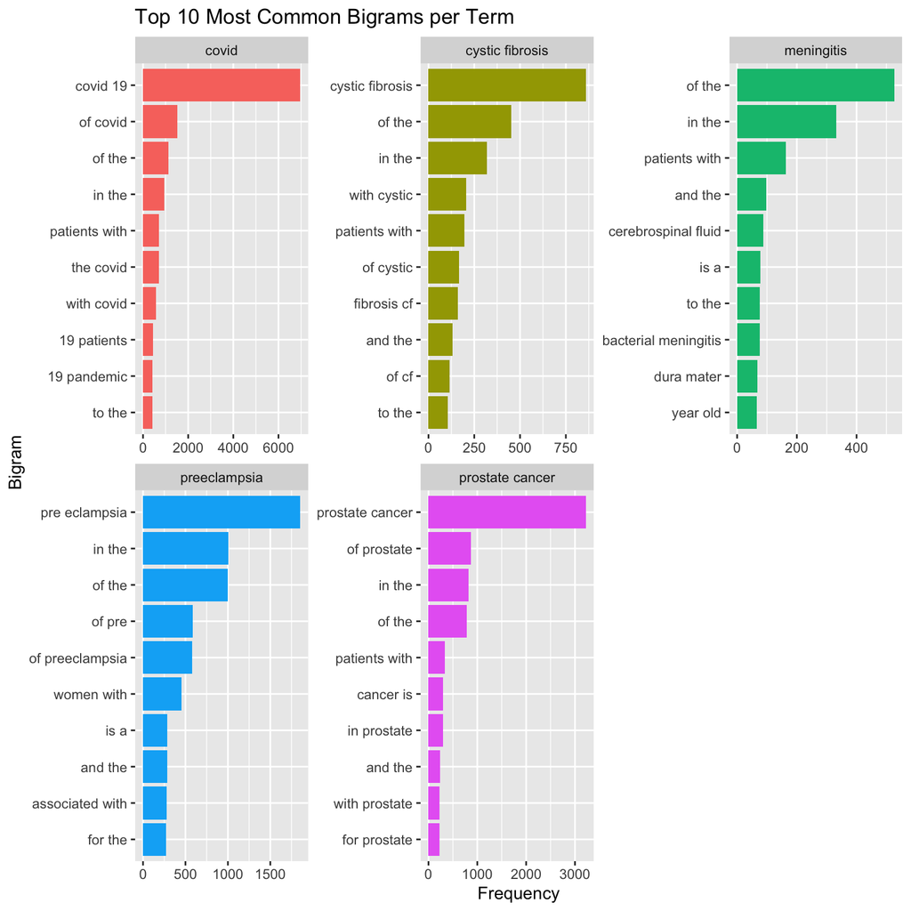

```r
top10_bigrams_by_term <- bigrams %>%
  count(term, bigram, sort = TRUE) %>% #frequency table
  group_by(term) %>%
  slice_max(n, n = 10)

top10_bigrams_by_term %>%
  ggplot(aes(x = reorder_within(bigram, n, term),
             y = n,
             fill = term)) +
  geom_col(show.legend = FALSE) +
  facet_wrap(~ term, scales = "free") +
  coord_flip() +
  scale_x_reordered() +
  labs(
    title = "Top 10 Most Common Bigrams per Term",
    x = "Bigram",
    y = "Frequency"
  )
```

**Generally, we can see that the top 10 bigrams include combinations such as “covid 19,” “of the,” “in the,” “prostate cancer,” “patients with,” “of covid,” “and the,” and “to the.” Many of these bigrams consist of stop-word combinations or pairings of a stop word with a disease name. This pattern makes sense because phrases like “of the” or “in the” are common grammatical structures in English writing. Overall, the top bigrams for each search term are primarily composed of disease names combined with stop words, or stop words paired together.**

**Question 4**

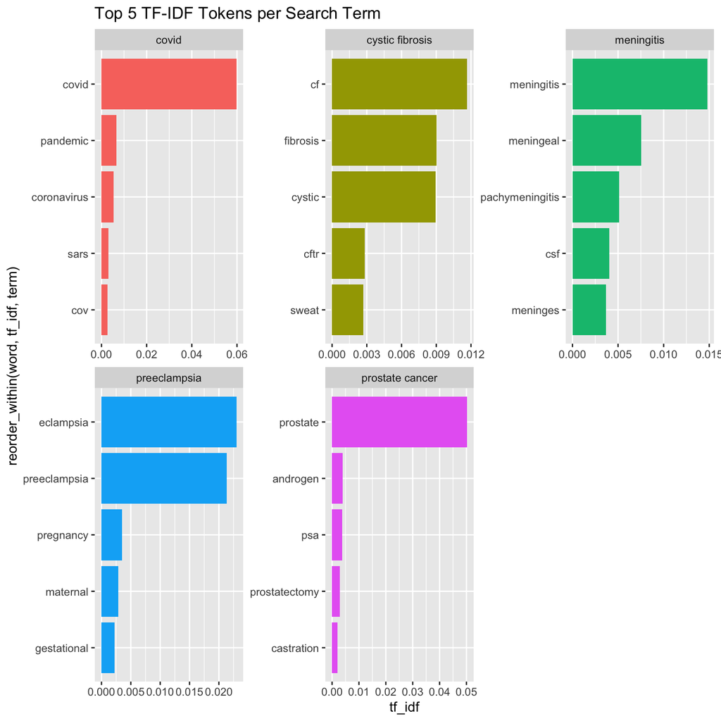

```r
word_counts <- pubmed %>%
  unnest_tokens(word, abstract) %>%
  count(term, word, sort = TRUE)

tfidf <- word_counts %>%
  bind_tf_idf(word, term, n) %>%  #Computes term frequency (TF) × inverse document frequency (IDF)
  arrange(desc(tf_idf))

top_tfidf <- tfidf %>%
  group_by(term) %>%
  slice_max(tf_idf, n = 5) %>%
  ungroup()

top_tfidf %>%
  ggplot(aes(x = reorder_within(word, tf_idf, term), y = tf_idf, fill = term)) +
  geom_col(show.legend = FALSE) +
  facet_wrap(~ term, scales = "free") +
  scale_x_reordered() +
  coord_flip() +
  labs(title = "Top 5 TF-IDF Tokens per Search Term")
```

**Question 5**

```r
library(textdata)
nrc_sent <- pubmed %>%
  unnest_tokens(word, abstract) %>%
  inner_join(get_sentiments("nrc"), by = "word") %>%
  count(term, sentiment, sort = TRUE)
#common sentiment per search term
common_nrc <- nrc_sent %>%
  group_by(term) %>%
  slice_max(n, n = 1) %>%
  arrange(term)
#Without positive/negative
common_nrc_nopn <- nrc_sent %>%
  filter(!sentiment %in% c("positive", "negative")) %>%
  group_by(term) %>%
  slice_max(n, n = 1)
```

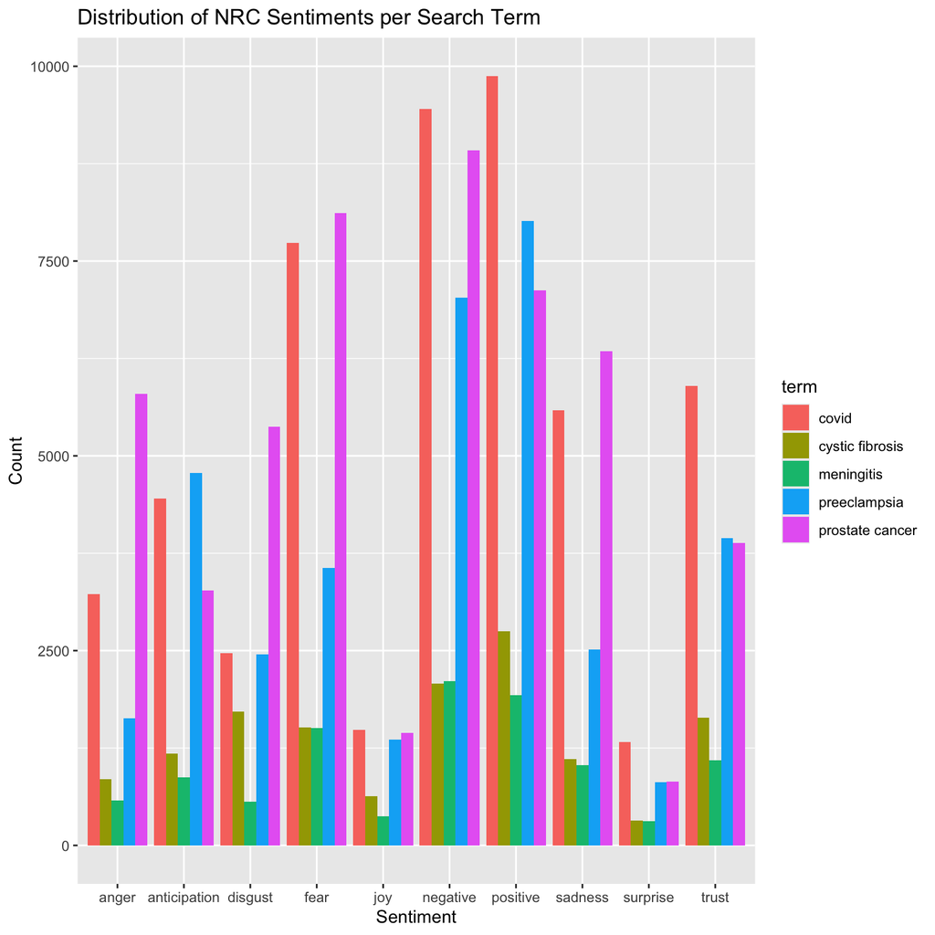

```r
nrc_sent %>%
  ggplot(aes(x = sentiment, y = n, fill = term)) +
  geom_col(position = "dodge") +
  labs(
    title = "Distribution of NRC Sentiments per Search Term",
    x = "Sentiment",
    y = "Count"
  )
```